# 588_project

## Data Processing

First processing data, figure out variable and data type.

```r
loan <- read.csv("loan_data.csv", head = T, stringsAsFactors=FALSE)
summary(loan)
```

```
##    Loan_ID             Gender            Married
##  Length:614         Length:614         Length:614
##  Class :character   Class :character   Class :character
##  Mode  :character   Mode  :character   Mode  :character
##
##
##
##
##   Dependents         Education         Self_Employed      ApplicantIncome
##  Length:614         Length:614         Length:614         Min.   :  150
##  Class :character   Class :character   Class :character   1st Qu.: 2878
##  Mode  :character   Mode  :character   Mode  :character   Median : 3812
##                                                           Mean   : 5403
##                                                           3rd Qu.: 5795
##                                                           Max.   :81000
##
##  CoapplicantIncome   LoanAmount    Loan_Amount_Term Credit_History
##  Min.   :    0     Min.   :  9.0   Min.   : 12      Min.   :0.0000
##  1st Qu.:    0     1st Qu.:100.0   1st Qu.:360      1st Qu.:1.0000
##  Median : 1188     Median :128.0   Median :360      Median :1.0000
##  Mean   : 1621     Mean   :146.4   Mean   :342      Mean   :0.8422
##  3rd Qu.: 2297     3rd Qu.:168.0   3rd Qu.:360      3rd Qu.:1.0000
##  Max.   :41667     Max.   :700.0   Max.   :480      Max.   :1.0000
##                    NA's   :22      NA's   :14       NA's   :50
##  Property_Area      Loan_Status
##  Length:614         Length:614
##  Class :character   Class :character
##  Mode  :character   Mode  :character
##
##
##
##
```

```r
length(unique(loan$Gender))
```

```
## [1] 3
```

```r
unique(loan$Gender)  # missing value exists
```

```
## [1] "Male"   "Female" ""
```

```r
loan$Gender[loan$Gender==''] <- NA
loan$Gender[loan$Gender=='Male'] <- 1
loan$Gender[loan$Gender=='Female'] <- 0
sum(is.na(loan$Gender))
```

```
## [1] 13
```

```r
loan$Gender <- as.numeric(loan$Gender)
```

```r
length(unique(loan$Married))
```

```
## [1] 3
```

```r
unique(loan$Married)  # missing value exists
```

```
## [1] "No"  "Yes" ""
```

```r
loan$Married[loan$Married==''] <- NA
loan$Married[loan$Married=='Yes'] <- 1
loan$Married[loan$Married=='No'] <- 0
sum(is.na(loan$Married))
```

```
## [1] 3
```

```r
loan$Married <- as.numeric(loan$Married)
```

```r
length(unique(loan$Dependents))
```

```
## [1] 5
```

```r
unique(loan$Dependents)  # missing value exists
```

```
## [1] "0"  "1"  "2"  "3+" ""
```

```r
loan$Dependents[loan$Dependents==''] <- NA
loan$Dependents[loan$Dependents=='3+'] <- 3
sum(is.na(loan$Dependents))
```

```
## [1] 15
```

```r
loan$Dependents <- as.numeric(loan$Dependents)
```

```r
length(unique(loan$Education))
```

```
## [1] 2
```

```r
unique(loan$Education)  # no missing value
```

```
## [1] "Graduate"     "Not Graduate"
```

```r
loan$Education[loan$Education=='Graduate'] <- 1
loan$Education[loan$Education=='Not Graduate'] <- 0
loan$Education <- as.numeric(loan$Education)
```

```r
length(unique(loan$Self_Employed))
```

```
## [1] 3
```

```r
unique(loan$Self_Employed)  # missing value exists
```

```
## [1] "No"  "Yes" ""
```

```r
loan$Self_Employed[loan$Self_Employed==''] <- NA
loan$Self_Employed[loan$Self_Employed=='No'] <- 0
loan$Self_Employed[loan$Self_Employed=='Yes'] <- 1
sum(is.na(loan$Self_Employed))
```

```
## [1] 32
```

```r
loan$Self_Employed <- as.numeric(loan$Self_Employed)
```

```r
length(unique(loan$Property_Area))
```

```
## [1] 3
```

```r
unique(loan$Property_Area)  # no missing value
```

```
## [1] "Urban"     "Rural"     "Semiurban"
```

```r
loan$Property_Area[loan$Property_Area=='Rural'] <- 1
loan$Property_Area[loan$Property_Area=='Semiurban'] <- 2
loan$Property_Area[loan$Property_Area=='Urban'] <- 3
loan$Property_Area <- as.numeric(loan$Property_Area)
```

Dealing with missing data (numeric/binary/factor variables) separately

```r
# Removing data
loan_noca <- subset(loan, select = -c(Loan_ID, Loan_Status))
summary(loan_noca)
```

```
##      Gender          Married         Dependents       Education
##  Min.   :0.0000   Min.   :0.0000   Min.   :0.0000   Min.   :0.0000
##  1st Qu.:1.0000   1st Qu.:0.0000   1st Qu.:0.0000   1st Qu.:1.0000
##  Median :1.0000   Median :1.0000   Median :0.0000   Median :1.0000
##  Mean   :0.8136   Mean   :0.6514   Mean   :0.7629   Mean   :0.7818
##  3rd Qu.:1.0000   3rd Qu.:1.0000   3rd Qu.:2.0000   3rd Qu.:1.0000
##  Max.   :1.0000   Max.   :1.0000   Max.   :3.0000   Max.   :1.0000
##  NA's   :13       NA's   :3        NA's   :15
##  Self_Employed    ApplicantIncome CoapplicantIncome   LoanAmount
##  Min.   :0.0000   Min.   :  150   Min.   :    0     Min.   :  9.0
##  1st Qu.:0.0000   1st Qu.: 2878   1st Qu.:    0     1st Qu.:100.0
##  Median :0.0000   Median : 3812   Median : 1188     Median :128.0
##  Mean   :0.1409   Mean   : 5403   Mean   : 1621     Mean   :146.4
##  3rd Qu.:0.0000   3rd Qu.: 5795   3rd Qu.: 2297     3rd Qu.:168.0
##  Max.   :1.0000   Max.   :81000   Max.   :41667     Max.   :700.0
##  NA's   :32                                         NA's   :22
##  Loan_Amount_Term Credit_History   Property_Area
##  Min.   : 12      Min.   :0.0000   Min.   :1.000
##  1st Qu.:360      1st Qu.:1.0000   1st Qu.:1.000
##  Median :360      Median :1.0000   Median :2.000
##  Mean   :342      Mean   :0.8422   Mean   :2.037
##  3rd Qu.:360      3rd Qu.:1.0000   3rd Qu.:3.000
##  Max.   :480      Max.   :1.0000   Max.   :3.000
##  NA's   :14       NA's   :50
```

```r
library(mice)
# impute the missing values
imputed_noca <- mice(loan_noca, m=5, maxit=50, method = 'cart', seed = 666)
summary(imputed_noca)
```

```
## Class: mids
## Number of multiple imputations:  5
## Imputation methods:
##            Gender           Married        Dependents         Education
##            "cart"            "cart"            "cart"                ""
##     Self_Employed   ApplicantIncome CoapplicantIncome        LoanAmount
##            "cart"                ""                ""            "cart"
##  Loan_Amount_Term    Credit_History     Property_Area
##            "cart"            "cart"                ""
## PredictorMatrix:
##                 Gender Married Dependents Education Self_Employed
## Gender               0       1          1         1             1
## Married              1       0          1         1             1
## Dependents           1       1          0         1             1
## Education            1       1          1         0             1
## Self_Employed        1       1          1         1             0
## ApplicantIncome      1       1          1         1             1
##                 ApplicantIncome CoapplicantIncome LoanAmount
## Gender                        1                 1          1
## Married                       1                 1          1
## Dependents                    1                 1          1
## Education                     1                 1          1
## Self_Employed                 1                 1          1
## ApplicantIncome               0                 1          1
##                 Loan_Amount_Term Credit_History Property_Area
## Gender                         1              1             1
## Married                        1              1             1
## Dependents                     1              1             1
## Education                      1              1             1
## Self_Employed                  1              1             1
## ApplicantIncome                1              1             1
```

```r
library(VIM)
```

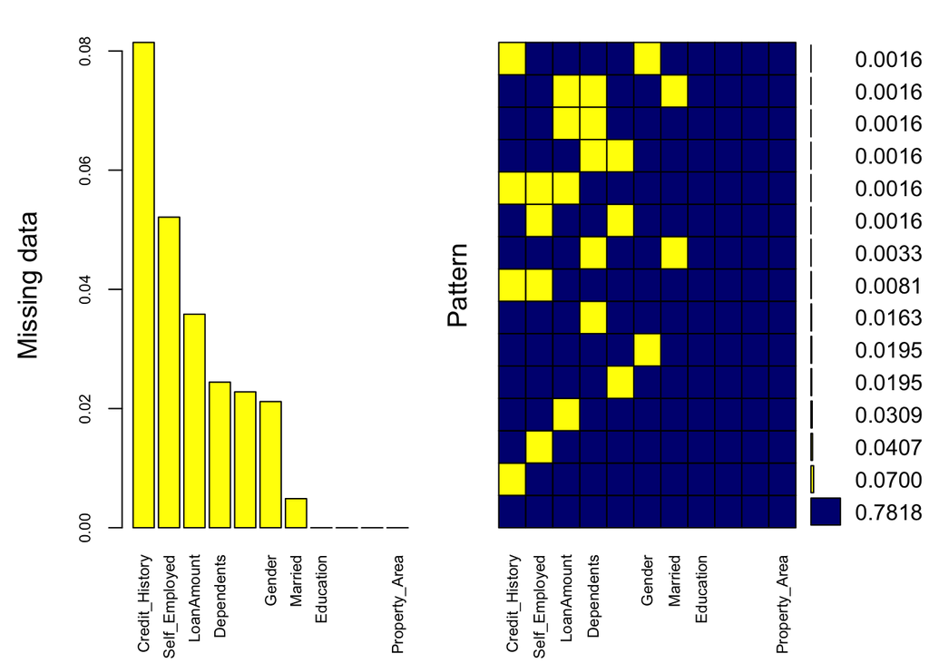

```
##
##  Variables sorted by number of missings:
##           Variable       Count
##     Credit_History 0.081433225
##      Self_Employed 0.052117264
##         LoanAmount 0.035830619
##         Dependents 0.024429967
##   Loan_Amount_Term 0.022801303
##             Gender 0.021172638
##            Married 0.004885993
##          Education 0.000000000
##    ApplicantIncome 0.000000000
##  CoapplicantIncome 0.000000000
##      Property_Area 0.000000000
```

```r
mice_plot <- aggr(loan_noca, col=c('navyblue','yellow'),
numbers=TRUE, sortVars=TRUE,
labels=names(loan_noca), cex.axis=.7,
gap=3, ylab=c("Missing data","Pattern"))
```

Histogram clearly depicts the influence of missing values in the variables. Right-hand-side plot gives the frequencies for different combination of variables missing. There are 78% values in the data set with no missing value. There are 7% missing values in credit history, 4% missing values in self employed and so on.

```r
# Check imputed values for both quantitative and qualitative data
imputed_noca$imp$Loan_Amount_Term
```

```
##       1   2   3   4   5
## 20  180 360  12 360 360
## 37  360 480 360 480 180
## 45  360 360 360 360 360
## 46  360 360 360 180 360
## 74  360 360 360 360 360
## 113 360 360 360 360 360
## 166 360 360 360 360 360
## 198 360 360 360 360 360
## 224 360 360 360 360 360
## 233 360 360 360 360 360
## 336 180 360 360 180 180
## 368 360 360 360 360 360
## 422 360 360 300 360 300
## 424 360 360 360 360 360
```

```r
imputed_noca$imp$Gender
```

```
##     1 2 3 4 5
## 24  1 1 1 1 1
## 127 1 1 1 1 1
## 172 0 1 1 1 1
## 189 0 1 1 1 1
## 315 1 1 1 1 1
## 335 1 1 1 1 1
## 461 1 1 0 1 0
## 468 1 1 1 1 1
## 478 1 1 1 1 1
## 508 0 0 0 0 1
## 577 1 1 1 1 1
## 589 1 0 0 1 1
## 593 0 0 1 0 0
```

```r
imputed_noca$imp$LoanAmount
```

```
##       1   2   3   4   5
## 1   115 156 133 133 156
## 36   88 110  97 104  95
## 64   72 166 166 125 125
## 82   66  81 113 160  94
## 96  194  84 130 140 133
## 103 436 496 304 320 304
## 104 132 182 142 151 236
## 114 175 200 128 141 132
## 128 144 119 114 109 124
## 203 105  40 157 124 100
## 285 480 152 500 260 360
## 306  17  17  53  30  17
## 323 186 186 168 162 120
## 339  30  53  98  30  35
## 388 178 128 136 131  93
## 436  75 152 182  75 152
## 438  46  70 102  60  63
## 480  90  95  84  90 109
## 525 186 150 186 187 148
## 551 187 205 205 187 187
## 552 131 150 172 178  98
## 606 115 120  95 115 121
```

```r
# Get complete data ( 3rd out of 5)
completeData <- complete(imputed_noca, 3)
sum(is.na(completeData))
```

```
## [1] 0
```

```r
head(completeData)
```

```
##   Gender Married Dependents Education Self_Employed ApplicantIncome
## 1      1       0          0         1             0            5849
## 2      1       1          1         1             0            4583
## 3      1       1          0         1             1            3000
## 4      1       1          0         0             0            2583
## 5      1       0          0         1             0            6000
## 6      1       1          2         1             1            5417
##   CoapplicantIncome LoanAmount Loan_Amount_Term Credit_History
## 1                 0        133              360              1
## 2              1508        128              360              1
## 3                 0         66              360              1
## 4              2358        120              360              1
## 5                 0        141              360              1
## 6              4196        267              360              1
##   Property_Area
## 1             3
## 2             1
## 3             3
## 4             3
## 5             3
## 6             3
```

```r
#check linearity
corr <- cor(completeData)
corr  ## only LoanAmount and ApplicantIncome have strong correlation
```

```
##                         Gender      Married  Dependents    Education
## Gender             1.000000000  0.375991049  0.19125588 -0.051519558
## Married            0.375991049  1.000000000  0.35218272 -0.014096840
## Dependents         0.191255877  0.352182724  1.00000000 -0.060066131
## Education         -0.051519558 -0.014096840 -0.06006613  1.000000000
## Self_Employed     -0.027539907 -0.007192312  0.07962191  0.003812234
## ApplicantIncome    0.062173710  0.049051745  0.12088932  0.140760276
## CoapplicantIncome  0.083183732  0.077759868  0.02769428  0.062289826
## LoanAmount         0.112738092  0.153236145  0.16081719  0.172740224
## Loan_Amount_Term  -0.076133843 -0.097638993 -0.07975410  0.070637315
## Credit_History    -0.004046871  0.007873267 -0.06247967  0.081955443
## Property_Area     -0.030199024  0.004414613  0.01265891  0.065243319
##                   Self_Employed ApplicantIncome CoapplicantIncome
## Gender             -0.027539907     0.062173710        0.08318373
## Married            -0.007192312     0.049051745        0.07775987
## Dependents          0.079621907     0.120889325        0.02769428
## Education           0.003812234     0.140760276        0.06228983
## Self_Employed       1.000000000     0.121855853        0.04634630
## ApplicantIncome     0.121855853     1.000000000       -0.11660458
## CoapplicantIncome   0.046346301    -0.116604581        1.00000000
## LoanAmount          0.120747748     0.578870152        0.17900202
## Loan_Amount_Term   -0.039113559    -0.040944020       -0.06285343
## Credit_History     -0.020612154    -0.007457878       -0.03611703
## Property_Area      -0.024976164    -0.009499695        0.01052192
##                    LoanAmount Loan_Amount_Term Credit_History
## Gender             0.11273809     -0.076133843   -0.004046871
## Married            0.15323615     -0.097638993    0.007873267
## Dependents         0.16081719     -0.079754104   -0.062479669
## Education          0.17274022      0.070637315    0.081955443
## Self_Employed      0.12074775     -0.039113559   -0.020612154
## ApplicantIncome    0.57887015     -0.040944020   -0.007457878
## CoapplicantIncome  0.17900202     -0.062853431   -0.036117029
## LoanAmount         1.00000000      0.041465793   -0.011655157
## Loan_Amount_Term   0.04146579      1.000000000    0.004808575
## Credit_History    -0.01165516      0.004808575    1.000000000
## Property_Area     -0.06021122     -0.086887505   -0.007510990
##                   Property_Area
## Gender             -0.030199024
## Married             0.004414613
## Dependents          0.012658911
## Education           0.065243319
## Self_Employed      -0.024976164
## ApplicantIncome    -0.009499695
## CoapplicantIncome   0.010521919
## LoanAmount         -0.060211217
## Loan_Amount_Term   -0.086887505
## Credit_History     -0.007510990
## Property_Area       1.000000000
```

```r
## Factor Analysis for a mix of continuous and categorical data
library(FactoMineR)
library(factoextra)
```

```r
## change data type in order to identify continuous and categorical data type
c = completeData
c$Gender[c$Gender=='1'] <- 'Male'
c$Gender[c$Gender=='0'] <- 'Female'
c$Married[c$Married=='1'] <- 'Yes'
c$Married[c$Married=='0'] <- 'No'
c$Dependents[c$Dependents=='3'] <- 'three+'
c$Dependents[c$Dependents=='2'] <- 'two'
c$Dependents[c$Dependents=='1'] <- 'one'
c$Dependents[c$Dependents=='0'] <- 'none'
c$Education[c$Education=='1'] <- 'Graduate'
c$Education[c$Education=='0'] <- 'Not Graduate'
c$Self_Employed[c$Self_Employed=='0'] <- 'No'
c$Self_Employed[c$Self_Employed=='1'] <- 'Yes'
c$Property_Area[c$Property_Area=='1'] <- 'Rural'
c$Property_Area[c$Property_Area=='2'] <- 'Semiurban'
c$Property_Area[c$Property_Area=='3'] <- 'Urban'
c$Credit_History[c$Credit_History=='1'] <- 'Yes'
c$Credit_History[c$Credit_History=='0'] <- 'No'
```

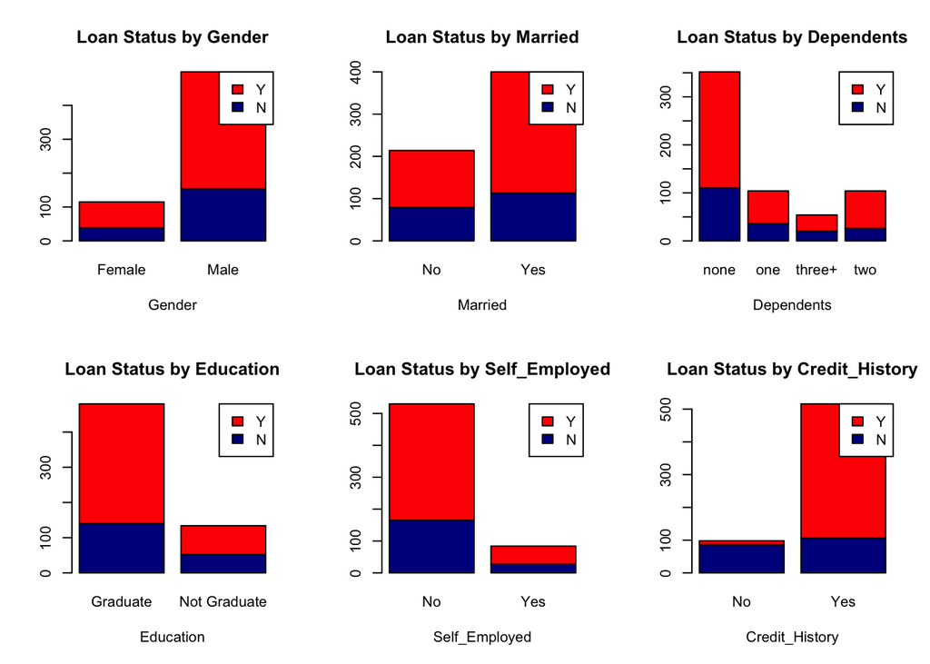

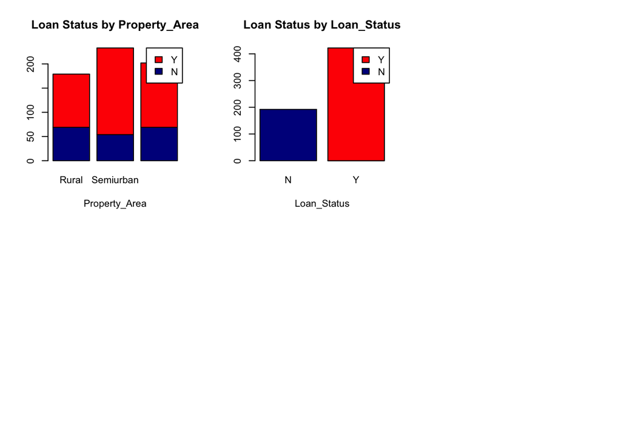

```r
# Check Categorical Variables
newdata = c
newdata$Loan_Status = loan$Loan_Status

par(mfrow = c(2,3))
categ = c(1,2,3,4,5,10,11,12)
for (i in 1:8){
  counts = table(newdata$Loan_Status, newdata[, categ[i]])
  barplot(counts, main=paste("Loan Status by", colnames(newdata[categ[i]])),
  xlab = colnames(newdata[categ[i]]), col = c("darkblue","red"),
  legend = rownames(counts), args.legend = list(x = "topright"))}  ## seems resonable
```

```r
#proportion of "Y" status
sum(loan$Loan_Status=="Y")/dim(loan)[1] ## Standard for checking data (0.6872964)
```

```
## [1] 0.6872964
```

```r
Loan_Status = loan$Loan_Status
newdata = data.frame(completeData, Loan_Status)

# ROC
library(ROCR)
library(pROC)
```

```r
rocplot = function(pred, truth){
  predob = prediction(pred, truth)
  perf = performance(predob, "tpr", "fpr")
  plot(perf)
}

# train&test
set.seed(666)
n_train = sample.int(n = nrow(newdata), size = floor(.70*nrow(newdata)), replace = F)
n_test = -n_train
train = newdata[n_train,]
test = newdata[n_test,]
n = dim(test)[1]
```

```r
# logistic regression
m_lr1 = glm(Loan_Status~., data = train, family = binomial)
summary(m_lr1)
```

```
##
## Call:
## glm(formula = Loan_Status ~ ., family = binomial, data = train)
##
## Deviance Residuals:
##     Min       1Q   Median       3Q      Max
## -2.1468  -0.3768   0.5603   0.6812   2.3567
##
## Coefficients:
##                     Estimate Std. Error z value Pr(>|z|)
## (Intercept)       -1.847e+00  1.115e+00  -1.657   0.0976 .
## Gender             6.257e-03  3.445e-01   0.018   0.9855
## Married            7.680e-01  3.160e-01   2.430   0.0151 *
## Dependents         5.776e-02  1.464e-01   0.394   0.6932
## Education          3.672e-01  3.201e-01   1.147   0.2512
## Self_Employed      1.866e-01  4.034e-01   0.463   0.6437
## ApplicantIncome    3.210e-06  2.859e-05   0.112   0.9106
## CoapplicantIncome -1.668e-05  6.071e-05  -0.275   0.7835
## LoanAmount        -3.087e-03  1.974e-03  -1.564   0.1179
## Loan_Amount_Term  -2.910e-03  2.480e-03  -1.173   0.2406
## Credit_History     3.848e+00  4.625e-01   8.320   <2e-16 ***
## Property_Area      3.365e-02  1.692e-01   0.199   0.8423
## ---
## Signif. codes:  0 '***' 0.001 '**' 0.01 '*' 0.05 '.' 0.1 ' ' 1
##
## (Dispersion parameter for binomial family taken to be 1)
##
##     Null deviance: 524.63  on 428  degrees of freedom
## Residual deviance: 385.91  on 417  degrees of freedom
## AIC: 409.91
##
## Number of Fisher Scoring iterations: 5
```

```r
prob_lr1 <- predict(m_lr1, test, type = "response")
pre_lr1 <- rep(0,n)
pre_lr1[prob_lr1>0.75] = "Y"
pre_lr1[prob_lr1<0.75] = "N"
mean(pre_lr1 == test[,"Loan_Status"])           ## accuracy 0.6918919
```

```
## [1] 0.6918919
```

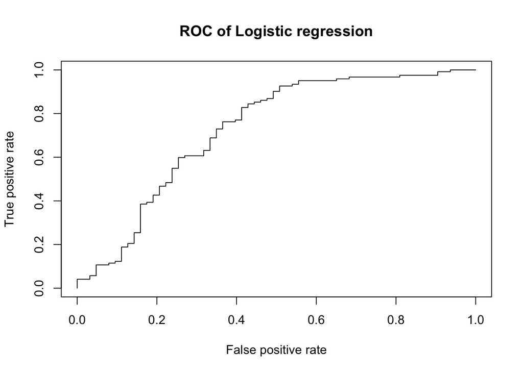

```r
rocplot(prob_lr1, loan[n_test,"Loan_Status"])
title(main = "ROC of Logistic regression")
```

```r
# Test AUC (used in classification analysis in order to determine which of the used models predicts the classes best.)
auc(roc(loan[n_test,"Loan_Status"], prob_lr1))  ## 0.7277
```

```
## Area under the curve: 0.7277
```

```r
# Train AUC
prob_lr2 <- predict(m_lr1, train, type = "response")
auc(roc(loan[n_train,"Loan_Status"], prob_lr2))  ## 0.78
```

```
## Area under the curve: 0.78
```

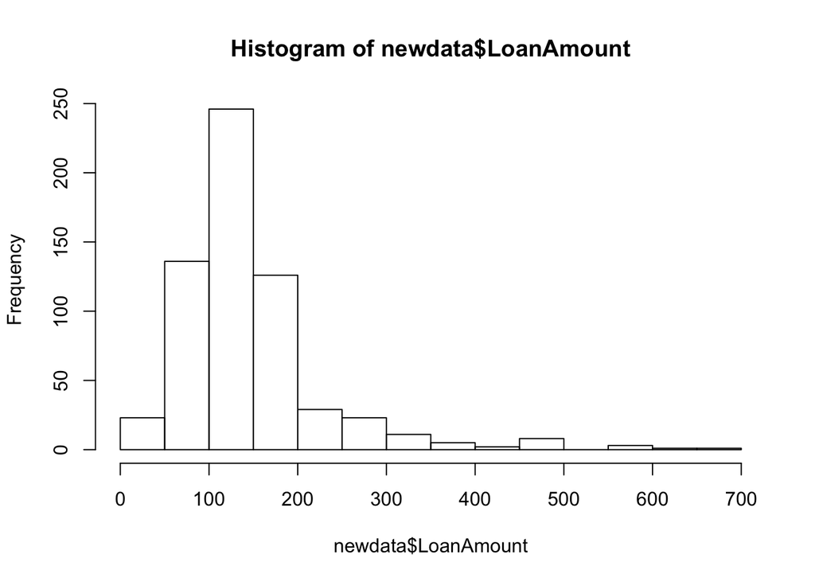

```r
hist(newdata$LoanAmount)
```

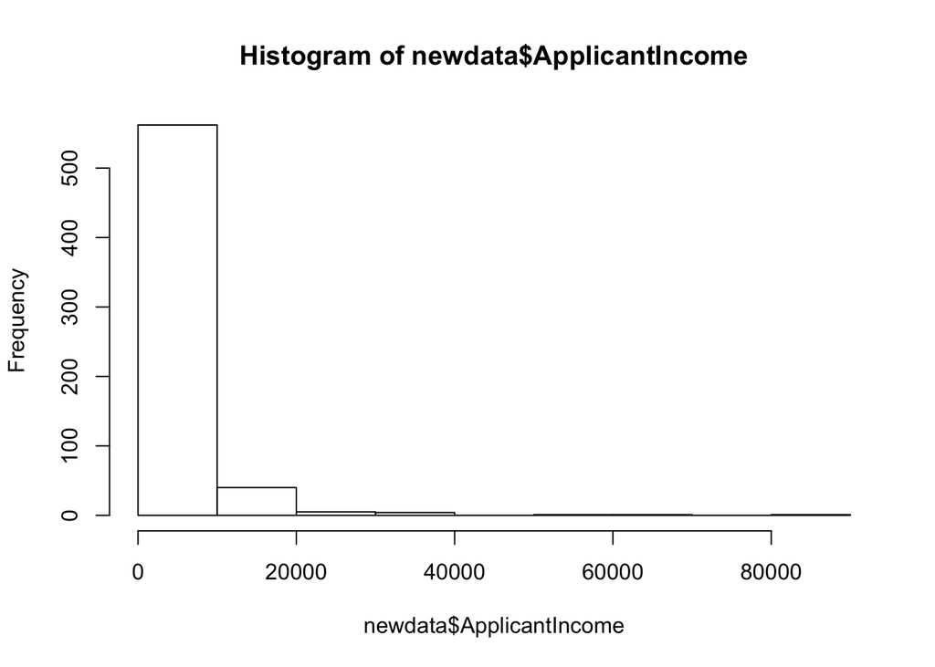

```r
hist(newdata$ApplicantIncome)
```

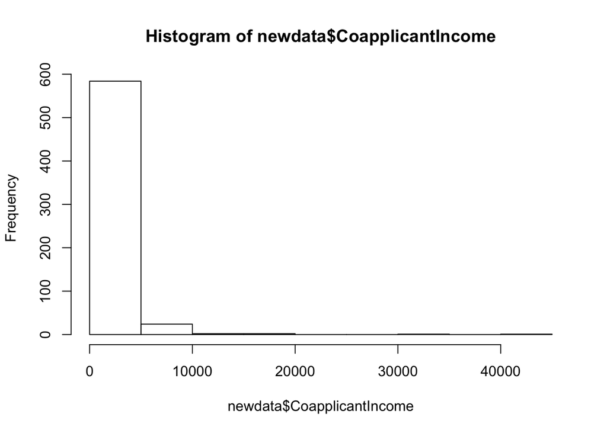

```r
hist(newdata$CoapplicantIncome)
```

```r
# Adjust extreme value
# Loan Amount
newdata$LoanAmount <- log(newdata$LoanAmount)
newdata$TotalIncome <- log(newdata$ApplicantIncome + newdata$CoapplicantIncome)
newdata <- subset(newdata, select = -c(ApplicantIncome, CoapplicantIncome))

# train&test
set.seed(666)
n_train = sample.int(n = nrow(newdata), size = floor(.70*nrow(newdata)), replace = F)
n_test = -n_train
train = newdata[n_train,]
test = newdata[n_test,]
n = dim(test)[1]
```

```r
#LDA
library(MASS)
m_lda <- lda(Loan_Status~., train)
pre_lda <- predict(m_lda, test)
mean(pre_lda$class == test[,"Loan_Status"])  ## accuracy 0.7783784
```

```
## [1] 0.7783784
```

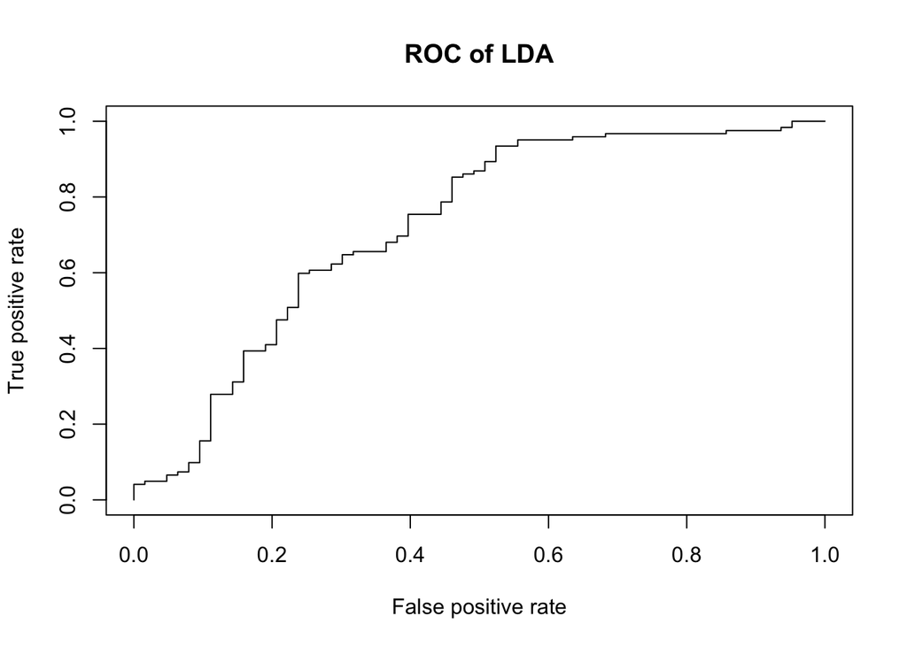

```r
# plot ROC
rocplot(pre_lda$posterior[,2], loan[n_test,"Loan_Status"])
title(main = "ROC of LDA")
```

```r
# Test AUC
auc(roc(loan[n_test,"Loan_Status"], pre_lda$posterior[,2]))  ## 0.7227
```

```
## Area under the curve: 0.7227
```

```r
# Train AUC
pre_lda2 <- predict(m_lda, train)
auc(roc(loan[n_train,"Loan_Status"], pre_lda2$posterior[,2])) ## 0.7758
```

```
## Area under the curve: 0.7758
```

```r
# QDA
m_qda1 <- qda(Loan_Status~., train)
pre_qda1 <- predict(m_qda1, test)
mean(pre_qda1$class == test[,"Loan_Status"]) ## accuracy 0.7675676
```

```
## [1] 0.7675676
```

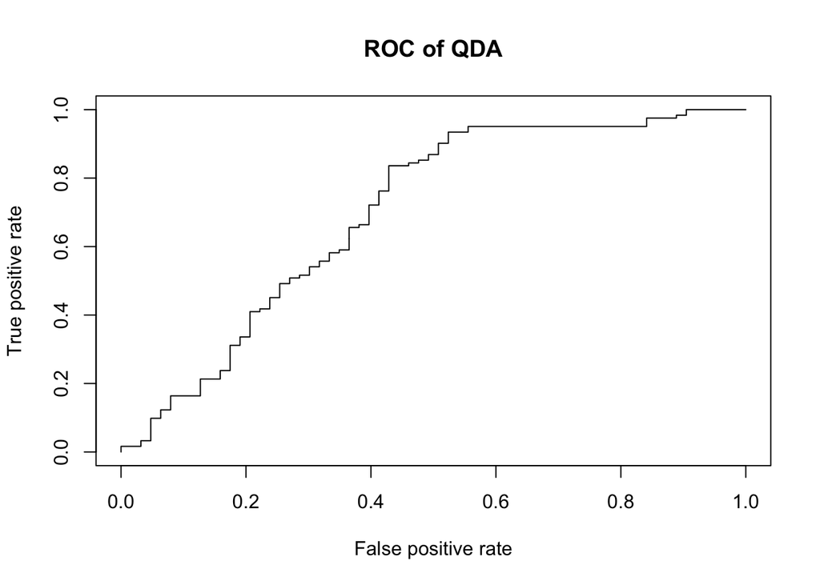

```r
# ROC
rocplot(pre_qda1$posterior[,2], loan[n_test,"Loan_Status"])
title(main = "ROC of QDA")
```

```r
# Test AUC
auc(roc(loan[n_test,"Loan_Status"], pre_qda1$posterior[,2])) ## 0.6983
```

```
## Area under the curve: 0.6983
```

```r
# Train AUC
pre_qda2 <- predict(m_qda1, train)
auc(roc(loan[n_train,"Loan_Status"], pre_qda2$posterior[,2])) ## 0.8045
```

```
## Area under the curve: 0.8045
```

```r
# KNN
library(class)
LoanStatus_train <- newdata$Loan_Status[n_train]
training1 <- newdata[n_train, -which(names(newdata) == "Loan_Status")]
testing1 <- newdata[n_test, -which(names(newdata) == "Loan_Status")]
set.seed(666)
num <- 0
a_value <- 0.5
for (i in seq(1:100)) {
  pre_knn <- knn(training1, testing1, LoanStatus_train, k = i, prob=TRUE)
  auc_value <- auc(roc(loan[n_test,"Loan_Status"], attributes(pre_knn)$prob))
  if (auc_value > a_value){
    a_value = auc_value
    num = i
  }
}
num ## k = 17
```

```
## [1] 17
```

```r
a_value ## AUC 0.7542
```

```
## Area under the curve: 0.7542
```

```r
mean(knn(training1, testing1, LoanStatus_train, k = 17) == test[,"Loan_Status"])  ## accuracy 0.6918919
```

```
## [1] 0.6918919
```

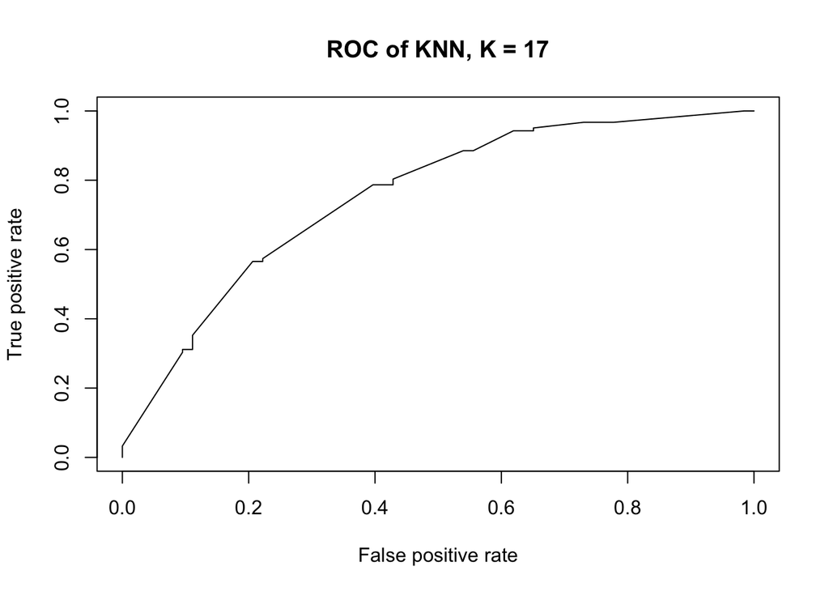

```r
# ROC
pre_knn <- knn(training1, testing1, LoanStatus_train, k = 17, prob=TRUE)
rocplot(attributes(pre_knn)$prob, loan[n_test,"Loan_Status"])
title(main = "ROC of KNN, K = 17")
```

```r
# Train AUC
pre_knn2 <- knn(training1, training1, LoanStatus_train, k = 17, prob=TRUE)
auc(roc(loan[n_train,"Loan_Status"], attributes(pre_knn2)$prob))   ## 0.8126
```

```
## Area under the curve: 0.8126
```

```r
# Support Vector Machine
library(e1071)
tune.out <- tune(svm, Loan_Status~., data=train, kernel="radial", ranges=list(cost=c(0.1,1,10,100,1000),  gamma=c(0.5,1,2,3,4)))
tune.out$best.model
```

```
##
## Call:
## best.tune(method = svm, train.x = Loan_Status ~ ., data = train,
##     ranges = list(cost = c(0.1, 1, 10, 100, 1000), gamma = c(0.5,
##         1, 2, 3, 4)), kernel = "radial")
##
##
## Parameters:
##    SVM-Type:  C-classification
##  SVM-Kernel:  radial
##        cost:  1
##       gamma:  0.5
##
## Number of Support Vectors:  325
```

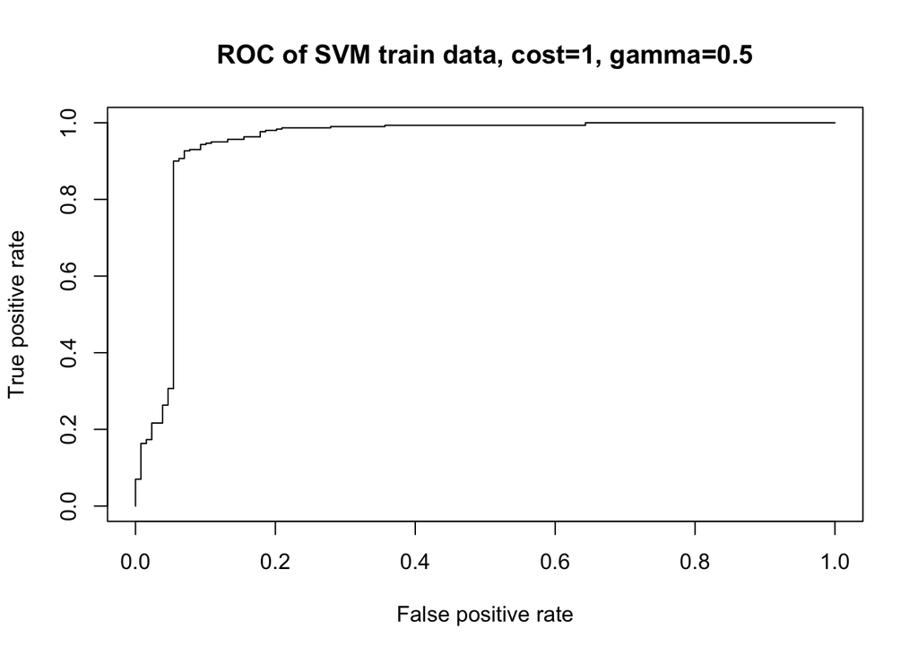

```r
## Train data
pred <- predict(tune.out$best.model, train, decision.values=T)
fitted <- attr(pred, "decision.values")
fitted <- as.numeric(fitted)
rocplot(fitted, loan[n_train,"Loan_Status"])
title(main = "ROC of SVM train data, cost=1, gamma=0.5")
```

```r
auc(roc(loan[n_train,"Loan_Status"], fitted))  ## AUC 0.9454
```

```
## Area under the curve: 0.9454
```

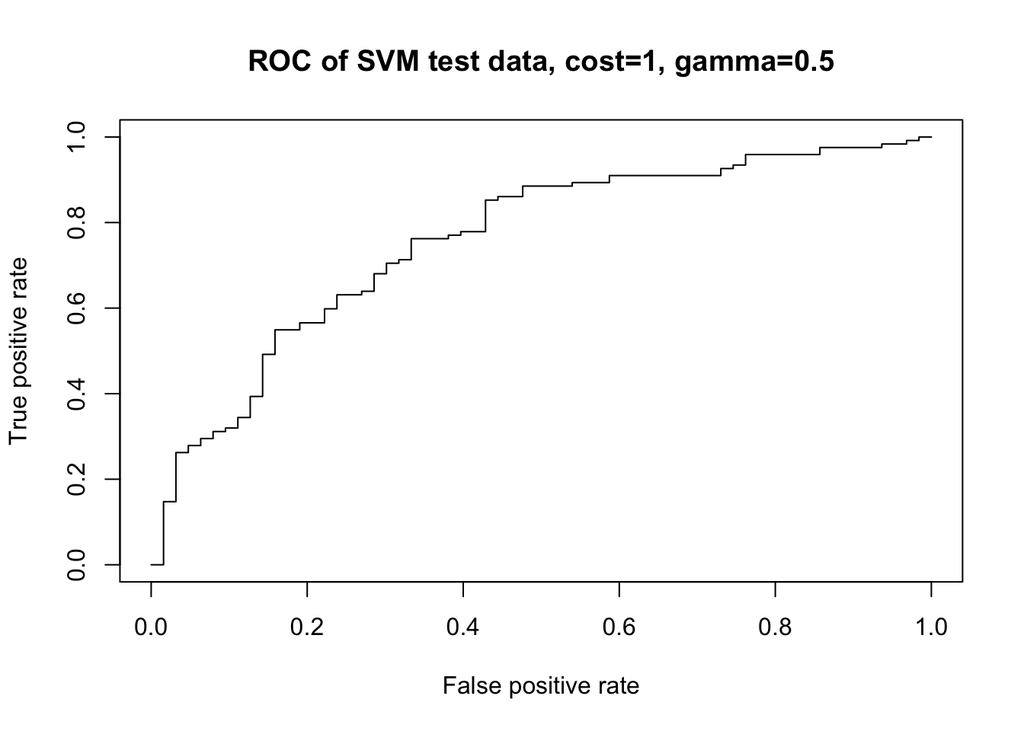

```r
## Test data
pred <- predict(tune.out$best.model, test, decision.values=T)
fitted <- attr(pred, "decision.values")
fitted <- as.numeric(fitted)
rocplot(fitted, loan[n_test,"Loan_Status"])
title(main = "ROC of SVM test data, cost=1, gamma=0.5")
```

```r
auc(roc(loan[n_test,"Loan_Status"], fitted))  ## AUC 0.7575
```

```
## Area under the curve: 0.7575
```

```r
mean(predict(tune.out$best.model, test) == test[,"Loan_Status"])  ## accuracy 0.7081081
```

```
## [1] 0.7081081
```

```r
## Bagging
set.seed(123)
library(adabag)
```

```r
bag = bagging(Loan_Status~., train, boos = TRUE, mfinal = 100)
pre_bag = predict.bagging(bag, test)
pre_bag_tr = predict.bagging(bag, train)

# Importance plot
bag$imp
```

```
##   Credit_History       Dependents        Education           Gender
##       66.9804862        1.6905715        0.8368996        0.6188675
## Loan_Amount_Term       LoanAmount          Married    Property_Area
##        0.1965226        8.4104471        1.7828583        2.2771816
##    Self_Employed      TotalIncome
##        0.4355478       16.7706178
```

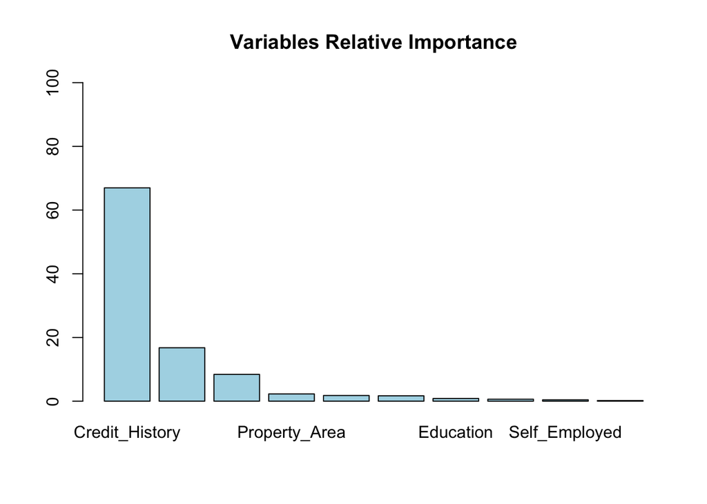

```r
barplot(bag$imp[order(bag$imp, decreasing = TRUE)],
ylim = c(0, 100), main = "Variables Relative Importance",
col = "lightblue")
```

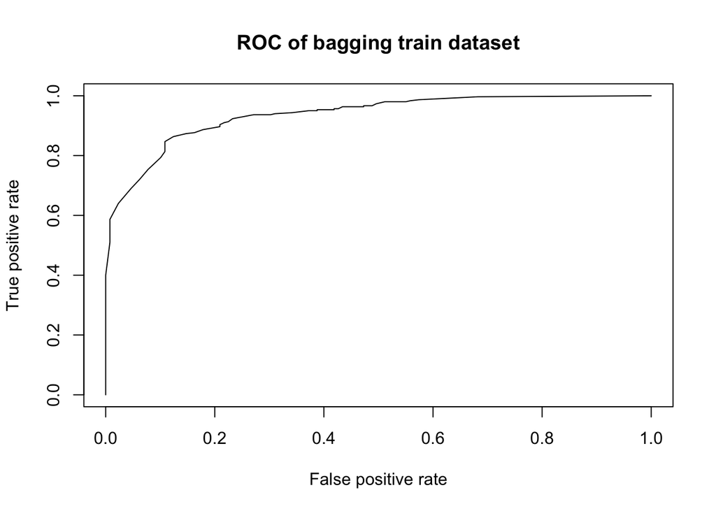

```r
## Train data
pre_bag_tr$prob = data.frame(pre_bag_tr$prob)
rocplot(pre_bag_tr$prob[,2], loan[n_train,"Loan_Status"])
title(main = "ROC of bagging train dataset")
```

```r
auc(roc(loan[n_train,"Loan_Status"], pre_bag_tr$prob[,2])) ## 0.9355
```

```
## Area under the curve: 0.9355
```

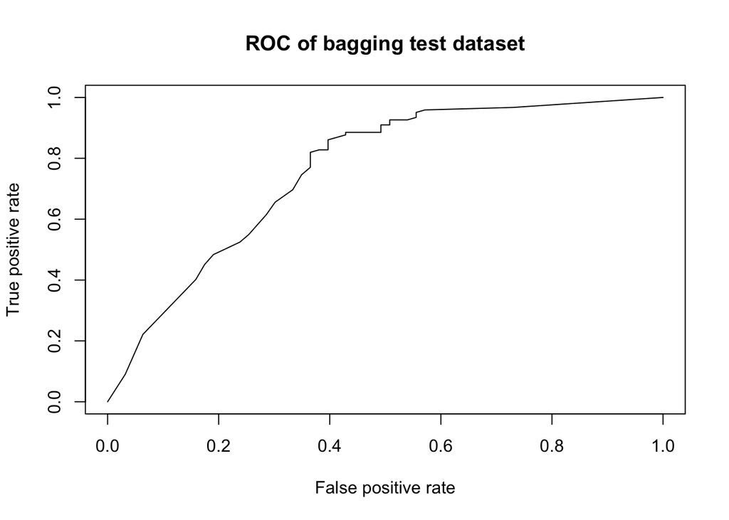

```r
## Test data
rocplot(pre_bag[['prob']][,2], loan[n_test,"Loan_Status"])
title(main = "ROC of bagging test dataset")
```

```r
auc(roc(loan[n_test,"Loan_Status"], pre_bag[['prob']][,2]))  ## 0.7583
```

```
## Area under the curve: 0.7583
```

```r
mean(pre_bag$class == test[,"Loan_Status"])  ## accuracy 0.7675676
```

```
## [1] 0.7675676
```

```r
## Boosting
set.seed(123)
library(adabag)
boost = boosting(Loan_Status~., train, boos = TRUE, mfinal = 100)
pre_boost = predict.boosting(boost, test)
pre_boost_tr = predict.boosting(boost, train)
boost$imp
```

```
##   Credit_History       Dependents        Education           Gender
##         5.715747         5.569489         2.395312         1.766451
## Loan_Amount_Term       LoanAmount          Married    Property_Area
##         2.822640        30.683041         2.770263         6.135234
##    Self_Employed      TotalIncome
##         1.775609        40.366215
```

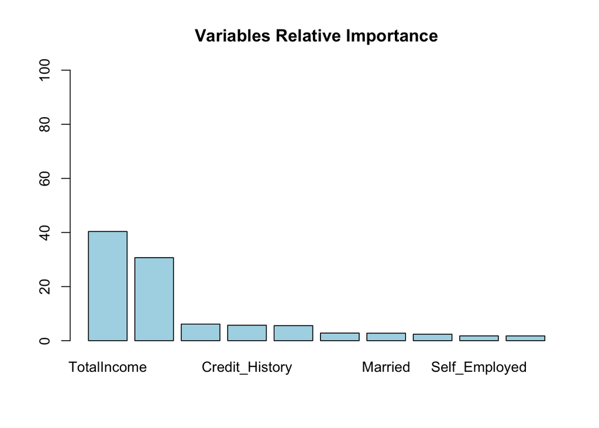

```r
barplot(boost$imp[order(boost$imp, decreasing = TRUE)],
 ylim = c(0, 100), main = "Variables Relative Importance",
col = "lightblue")
```

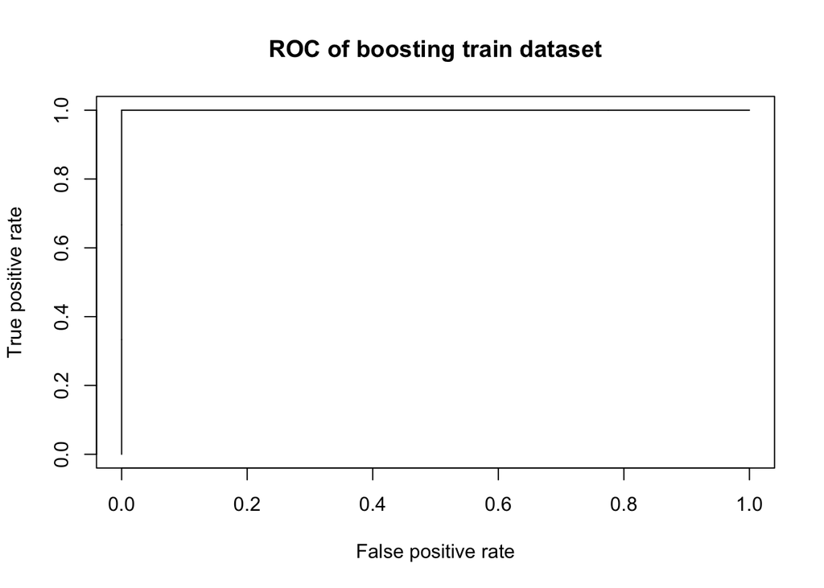

```r
## Train data
rocplot(pre_boost_tr$prob[,2], loan[n_train,"Loan_Status"])
title(main = "ROC of boosting train dataset")
```

```r
auc(roc(loan[n_train,"Loan_Status"], pre_boost_tr$prob[,2])) ## 1
```

```
## Area under the curve: 1
```

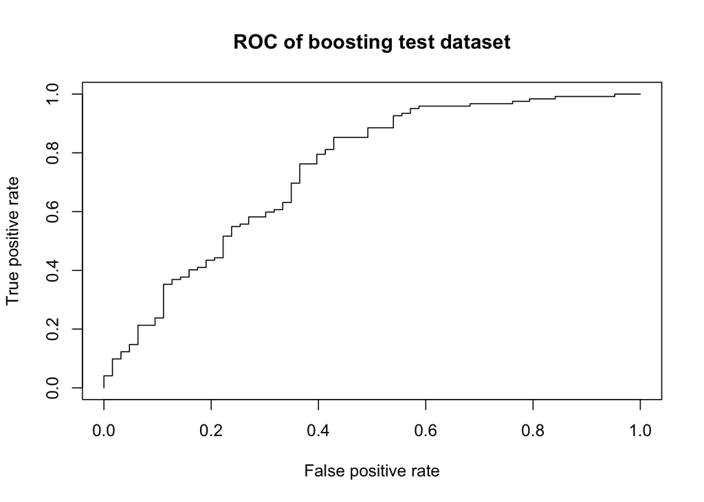

```r
## Test data
rocplot(pre_boost$prob[,2], loan[n_test,"Loan_Status"])
title(main = "ROC of boosting test dataset")
```

```r
auc(roc(loan[n_test,"Loan_Status"], pre_boost$prob[,2]))  ## 0.74
```

```
## Area under the curve: 0.74
```

```r
mean(pre_boost$class == test[,"Loan_Status"])  ## accuracy 0.7513514
```

```
## [1] 0.7513514
```

```r
## Ramdom Forest
library(randomForest)
```

```r
set.seed(123)
m_rf1 <- randomForest(Loan_Status~., train, ntree = 500, mtry = 3, importance = TRUE)
pre_rf1 <- predict(m_rf1, test, type="prob")
importance(m_rf1)                                 ## Credit_History
```

```
##                           N           Y MeanDecreaseAccuracy
## Gender           -4.4678957  2.57961581           0.22210252
## Married          -1.5465757  2.89345374           1.80353157
## Dependents        1.2548959  0.86891900           1.38071148
## Education        -1.0687858  0.32013040          -0.35938209
## Self_Employed    -0.5164406  0.58883445           0.17313919
## LoanAmount       -3.4016852 15.14629603          11.52121584
## Loan_Amount_Term -1.0984109 -0.09398737          -0.58102612
## Credit_History   68.6843935 66.78890759          77.80608026
## Property_Area     0.2778521 -0.17382001          -0.01433776
## TotalIncome      -2.7981170 13.70060447          12.11774226
##                  MeanDecreaseGini
## Gender                   3.088191
## Married                  4.157259
## Dependents               8.107824
## Education                4.177846
## Self_Employed            3.351516
## LoanAmount              32.453268
## Loan_Amount_Term         5.966274
## Credit_History          51.228497
## Property_Area            8.027568
## TotalIncome             38.478777
```

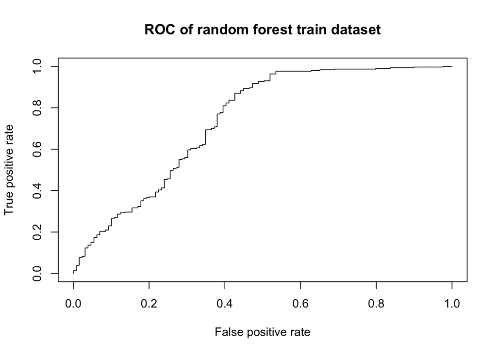

```r
## Train data
rocplot(m_rf1$votes[,2], loan[n_train,"Loan_Status"])
title(main = "ROC of random forest train dataset")
```

```r
auc(roc(loan[n_train,"Loan_Status"], m_rf1$votes[,2])) ## 0.7383
```

```
## Area under the curve: 0.7383
```

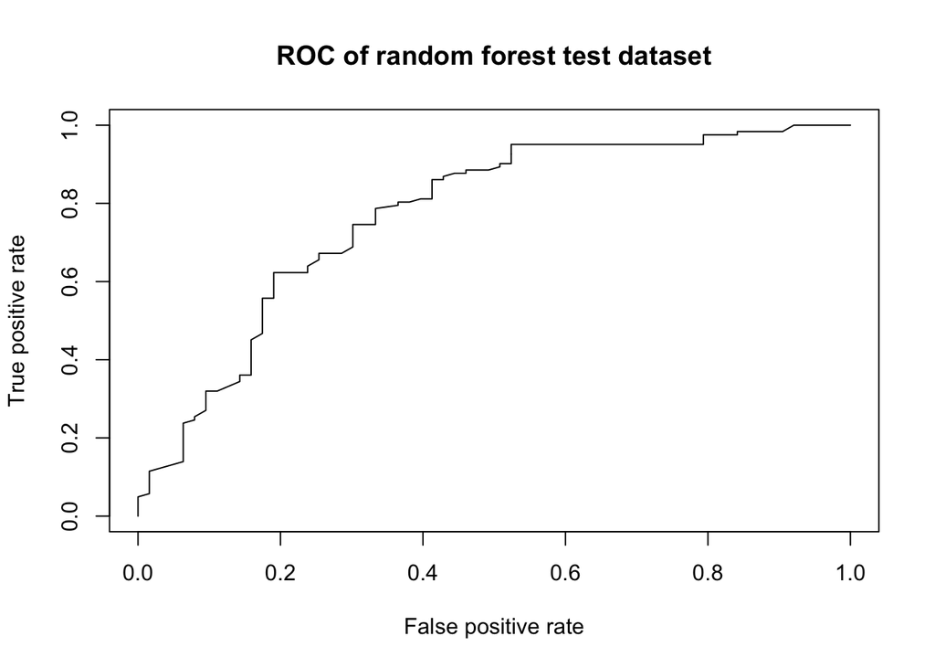

```r
## Test data
rocplot(pre_rf1[,2], loan[n_test,"Loan_Status"])
title(main = "ROC of random forest test dataset")
```

```r
auc(roc(loan[n_test,"Loan_Status"], pre_rf1[,2]))  ## 0.7702
```

```
## Area under the curve: 0.7702
```

```r
mean(predict(m_rf1, test) == test[,"Loan_Status"])  ## accuracy 0.7675676
```

```
## [1] 0.7675676
```

```r
## Neural Network
library(tidyverse)
library(neuralnet)
library(GGally)
```

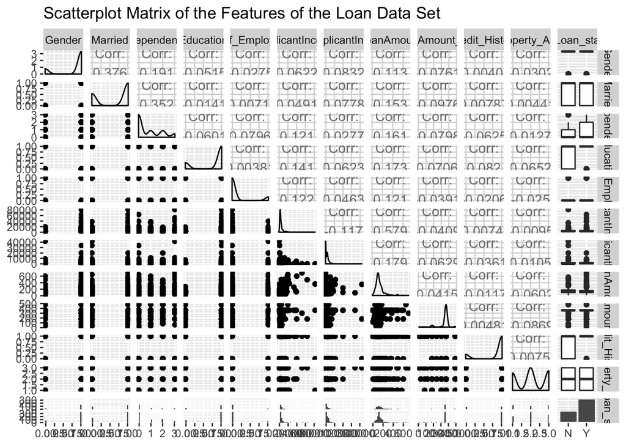

```r
Loan_sta <- loan$Loan_Status
nnewdata <- data.frame(completeData, Loan_sta)
ggpairs(nnewdata, title = "Scatterplot Matrix of the Features of the Loan Data Set")
```

```r
## scale features to fall on the closed [0,1] interval
Loan_sta[Loan_sta == 'Y'] <- 1
Loan_sta[Loan_sta == 'N'] <- 0
Loan_sta <- as.numeric(Loan_sta)
nnewdata <- data.frame(completeData, Loan_sta)
scale01 <- function(x) {
    (x - min(x))/(max(x) - min(x))
}
nnewdata['Dependents'] <- scale01(nnewdata['Dependents'])
nnewdata['ApplicantIncome'] <- scale01(nnewdata['ApplicantIncome'])
nnewdata['CoapplicantIncome'] <- scale01(nnewdata['CoapplicantIncome'])
nnewdata['LoanAmount'] <- scale01(nnewdata['LoanAmount'])
nnewdata['Loan_Amount_Term'] <- scale01(nnewdata['Loan_Amount_Term'])
nnewdata['Property_Area'] <- scale01(nnewdata['Property_Area'])
```

```r
set.seed(666)
n_train2 = sample.int(n = nrow(nnewdata), size = floor(.70*nrow(nnewdata)), replace = F)
n_test2 = -n_train2
train2 = nnewdata[n_train2,]
test2 = nnewdata[n_test2,]
```

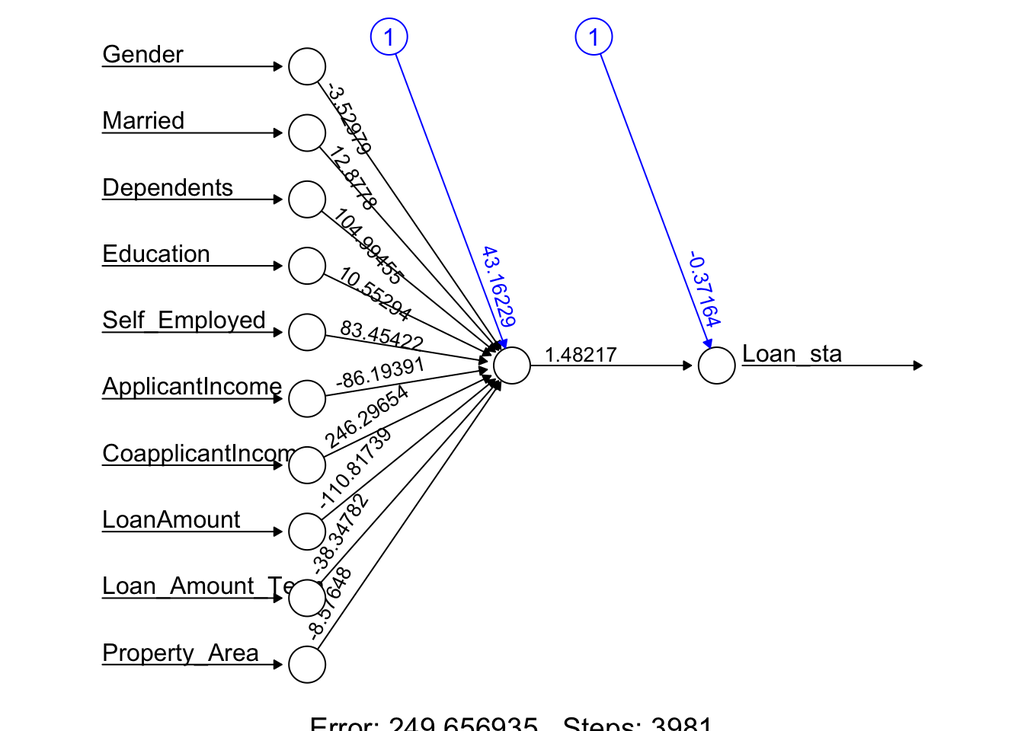

```r
## construct a 1-hidden layer ANN with 1 neuron
set.seed(123)
loan_NN1 <- neuralnet(Loan_sta ~ Gender+Married+Dependents+Education+Self_Employed+ApplicantIncome+
                        CoapplicantIncome+LoanAmount+Loan_Amount_Term+Property_Area, train2,
                      linear.output = FALSE, err.fct = "ce", likelihood = TRUE)

plot(loan_NN1, rep = "best")
```

The black lines show the connections between each layer and the weights on each connection while the blue lines show the bias term added in each step. The bias can be thought as the intercept of a linear model.

The error displayed in this plot is the cross-entropy error, which is a measure of the differences between the predicted and observed output for each of the observations in the Loan data set.

```r
loan_NN1_Train_Error <- loan_NN1$result.matrix[1, 1]
paste("CE Error: ", round(loan_NN1_Train_Error, 3))
```

```
## [1] "CE Error:  249.657"
```

```r
loan_NN1_AIC <- loan_NN1$result.matrix[4, 1]
paste("AIC: ", round(loan_NN1_AIC, 3))
```

```
## [1] "AIC:  525.314"
```

```r
loan_NN2_BIC <- loan_NN1$result.matrix[5, 1]
paste("BIC: ", round(loan_NN2_BIC, 3))
```

```
## [1] "BIC:  578.113"
```

```r
set.seed(123)
loan_NN2 <- neuralnet(Loan_sta ~ Gender+Married+Dependents+Education+Self_Employed+ApplicantIncome+
                        CoapplicantIncome+LoanAmount+Loan_Amount_Term+Property_Area, train2,
            linear.output = FALSE, err.fct = "ce", likelihood = TRUE, hidden = c(1,2))

set.seed(123)
loan_NN3 <- neuralnet(Loan_sta ~ Gender+Married+Dependents+Education+Self_Employed+ApplicantIncome+
                        CoapplicantIncome+LoanAmount+Loan_Amount_Term+Property_Area, train2,
                      linear.output = FALSE, err.fct = "ce", likelihood = TRUE, hidden = 7)
set.seed(123)
loan_NN4 <- neuralnet(Loan_sta ~ Gender+Married+Dependents+Education+Self_Employed+ApplicantIncome+
                        CoapplicantIncome+LoanAmount+Loan_Amount_Term+Property_Area, train2,
                      linear.output = FALSE, err.fct = "ce", likelihood = TRUE, hidden = 4 )
```

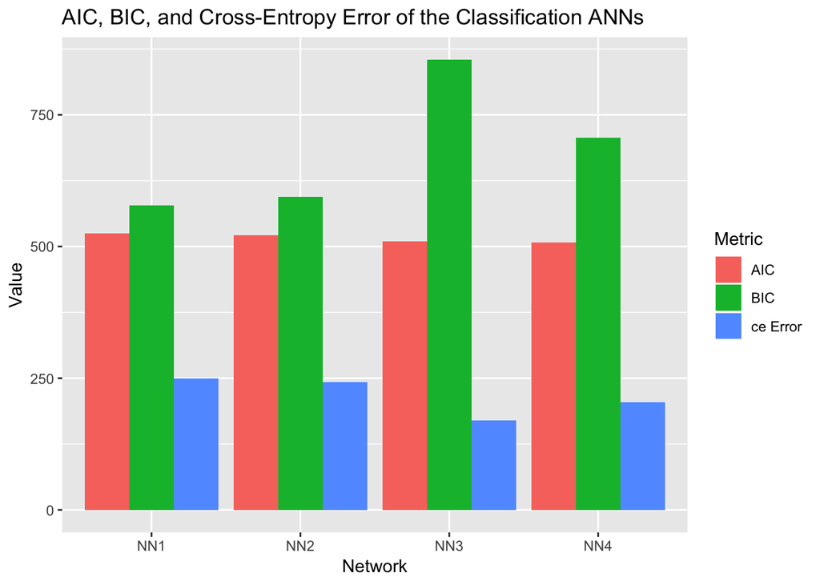

```r
# Bar plot of results
Class_NN_ICs <- tibble(Network = rep(c("NN1", "NN2", "NN3", "NN4"), each = 3),
    Metric = rep(c("AIC", "BIC", "ce Error"), length.out = 12), Value = c(loan_NN1$result.matrix[4,
        1], loan_NN1$result.matrix[5, 1], loan_NN1$result.matrix[1, 1],
        loan_NN2$result.matrix[4,
        1], loan_NN2$result.matrix[5, 1], loan_NN2$result.matrix[1, 1],
        loan_NN3$result.matrix[4, 1], loan_NN3$result.matrix[5, 1], loan_NN3$result.matrix[1, 1],             loan_NN4$result.matrix[4, 1], loan_NN4$result.matrix[5,
            1], loan_NN4$result.matrix[1, 1]))
Class_NN_ICs %>% ggplot(aes(Network, Value, fill = Metric)) + geom_col(position = "dodge") +
    ggtitle("AIC, BIC, and Cross-Entropy Error of the Classification ANNs")
```

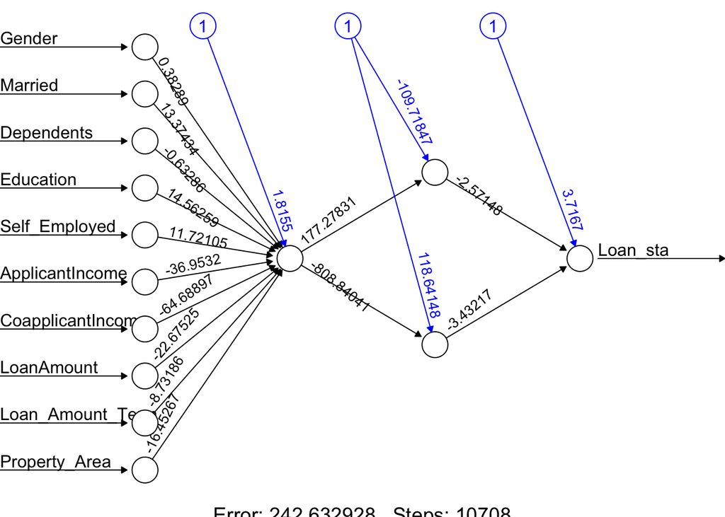

```r
plot(loan_NN2, rep = "best")
```

```r
temp_test <- subset(test2, select = c("Gender","Married","Dependents","Education","Self_Employed","ApplicantIncome","CoapplicantIncome","LoanAmount","Loan_Amount_Term","Property_Area"))
nn.results <- compute(loan_NN2, temp_test)
results <- data.frame(actual = test2$Loan_sta, prediction = nn.results$net.result)
results
```

```
##     actual   prediction
## 3        1 0.7586367560
## 7        1 0.5706551212
## 11       1 0.7586367560
## 12       1 0.9762630236
## 13       1 0.5706551212
## 16       1 0.5706551212
## 17       1 0.5706551212
## 20       1 0.7586367560
## 24       0 0.7586372263
## 28       1 0.5706551212
## 29       0 0.5706551212
## 32       0 0.5706551212
## 33       0 0.7586367560
## 35       0 0.5706551212
```

[output cut: 171 more lines]

```r
nn.results2 <- compute(loan_NN1, temp_test)
results2 <- data.frame(actual = test2$Loan_sta, prediction = nn.results2$net.result)

nn.results3 <- compute(loan_NN3, temp_test)
results3 <- data.frame(actual = test2$Loan_sta, prediction = nn.results3$net.result)

nn.results4 <- compute(loan_NN4, temp_test)
results4 <- data.frame(actual = test2$Loan_sta, prediction = nn.results4$net.result)
```

```r
## Test data
detach(package:neuralnet)
auc(roc(loan[n_test2,"Loan_Status"], results[["prediction"]]))
```

```
## Area under the curve: 0.5145719
```

```r
auc(roc(loan[n_test2,"Loan_Status"], results2[["prediction"]]))
```

```
## Area under the curve: 0.5310304
```

```r
auc(roc(loan[n_test2,"Loan_Status"], results3[["prediction"]]))
```

```
## Area under the curve: 0.5701926
```

```r
auc(roc(loan[n_test2,"Loan_Status"], results4[["prediction"]]))
```

```
## Area under the curve: 0.5156128
```

Problems that occur during neural network training is overfitting. The error on the training set is driven to a very small value, but when new data is presented to the network the error is large. The network has memorized the training examples, but it has not learned to generalize to new situations. One method for improving network generalization is to use a network that is just large enough to provide an adequate fit. Another one is using dropout.